# Processing label-free MS/MS data

- Show All Code
- Hide All Code
- View Source

Author

André F. B. Menezes, Beatrice Tropea, and Cormac Monaghan

Published

December 20, 2022

# 1 Introduction

This report describes the processing steps used to organize the label-free proteomics of *Escherichia* *coli* cultures bacterial data. This data was first analyzed by Margalit, Carolan, and Walsh (2022).

The report is organized as followed. Section 2 describes data import and management using the QFeatures package. Processing steps (filtering, imputation, and normalization) are discussed in Section 3. Finally, Section 4 presents a comparison between the processed data from the original paper and from the steps performed below.

# 2 Data import and management

The data from Margalit, Carolan, and Walsh (2022) experiment was first pre-processed using the [MaxQuant](https://www.maxquant.org/) software. MaxQuant provides an `evidence.txt` file that combines all the information about identified peptides and is the only file required for processing the data and performing downstream analysis.

For the first step, we read the evidence file, filter out contaminants and reverse sequences, remove the Tetracycline antibiotic, and pivot the matrix data in wide format.

```r
# Import the raw data (evidence)
data_raw <- read.delim("../data/evidence.txt")

cols <- list(
  charge = "Charge",
  sequence = 'Sequence',
  modified_sequence = 'Modified.sequence',
  modifications = 'Modifications',
  protein_group = 'Proteins',
  protein = 'Leading.Razor.Protein',
  experiment = 'Experiment',
  reverse = 'Reverse',
  contaminant = 'Contaminant',
  intensity = 'Intensity'
)
data_raw <- data_raw[, as.character(cols)]
colnames(data_raw) <- names(cols)
dplyr::glimpse(data_raw)
```

```
Rows: 206,409
Columns: 10
$ charge            <int> 2, 3, 2, 2, 3, 2, 2, 3, 2, 2, 3, 2, 2, 3, 2, 3, 2, 2…
$ sequence          <chr> "AAAAPVTGPLADDPIQETITFDDFAK", "AAAAPVTGPLADDPIQETITF…
$ modified_sequence <chr> "_AAAAPVTGPLADDPIQETITFDDFAK_", "_AAAAPVTGPLADDPIQET…
$ modifications     <chr> "Unmodified", "Unmodified", "Unmodified", "Unmodifie…
$ protein_group     <chr> "P00959", "P00959", "P00959", "P00959", "P00959", "P…
$ protein           <chr> "P00959", "P00959", "P00959", "P00959", "P00959", "P…
$ experiment        <chr> "Amp1", "Amp2", "Amp2", "cip1", "cip2", "cip2", "cip…
$ reverse           <chr> "", "", "", "", "", "", "", "", "", "", "", "", "", …
$ contaminant       <chr> "", "", "", "", "", "", "", "", "", "", "", "", "", …
$ intensity         <dbl> 13593000, 65949000, 155880000, 115540000, 128050000,…
```

```r
# Filters out contaminants and reverse sequences
data_raw <- data_raw[
  which(data_raw$contaminant != "+" & data_raw$reverse != "+"), ]

# Removing Tetracycline group
data_raw <- data_raw[!(data_raw$experiment %in% c("Tet2", "Tet3", "Tet4")), ]

# Creating a unique id, since there are multiple peptides corresponding to the
# same sequence
chosen_cols <- c("modified_sequence", "protein", "experiment", "intensity")
data_raw <- data_raw[, chosen_cols] |>
  dplyr::group_by(experiment, modified_sequence, protein) |>
  dplyr::mutate(number_peptides = dplyr::n()) |>
  dplyr::ungroup() |>
  dplyr::arrange(experiment, modified_sequence, protein)
data_raw$unique_id <- seq.int(1, nrow(data_raw))

# Pivot to create the data matrix at PSM's level
pivotted_psms <- tidyr::pivot_wider(
  data = data_raw,
  id_cols = c(unique_id, number_peptides, modified_sequence, protein),
  names_from = experiment,
  values_from = intensity)
rm(data_raw)
dplyr::glimpse(pivotted_psms)
```

```
Rows: 182,018
Columns: 19
$ unique_id         <int> 1, 2, 3, 4, 5, 6, 7, 8, 9, 10, 11, 12, 13, 14, 15, 1…
$ number_peptides   <int> 1, 1, 1, 1, 1, 1, 1, 1, 1, 1, 1, 1, 1, 1, 1, 1, 2, 2…
$ modified_sequence <chr> "_(ac)SEQHAQGADAVVDLNNELK_", "_(ac)SEQNNTEM(ox)TFQIQ…
$ protein           <chr> "P0A8N3", "P0AG86", "P0AG86", "P0AFG6", "P25738", "P…
$ Amp1              <dbl> 15744000, 41416000, 26716000, 23443000, 5987700, 510…
$ Amp2              <dbl> NA, NA, NA, NA, NA, NA, NA, NA, NA, NA, NA, NA, NA, …
$ Amp3              <dbl> NA, NA, NA, NA, NA, NA, NA, NA, NA, NA, NA, NA, NA, …
$ Cef2              <dbl> NA, NA, NA, NA, NA, NA, NA, NA, NA, NA, NA, NA, NA, …
$ Cef3              <dbl> NA, NA, NA, NA, NA, NA, NA, NA, NA, NA, NA, NA, NA, …
$ Cef4              <dbl> NA, NA, NA, NA, NA, NA, NA, NA, NA, NA, NA, NA, NA, …
$ cip1              <dbl> NA, NA, NA, NA, NA, NA, NA, NA, NA, NA, NA, NA, NA, …
$ cip2              <dbl> NA, NA, NA, NA, NA, NA, NA, NA, NA, NA, NA, NA, NA, …
$ cip3              <dbl> NA, NA, NA, NA, NA, NA, NA, NA, NA, NA, NA, NA, NA, …
$ Cont1             <dbl> NA, NA, NA, NA, NA, NA, NA, NA, NA, NA, NA, NA, NA, …
$ Cont2             <dbl> NA, NA, NA, NA, NA, NA, NA, NA, NA, NA, NA, NA, NA, …
$ Cont4             <dbl> NA, NA, NA, NA, NA, NA, NA, NA, NA, NA, NA, NA, NA, …
$ Imp1              <dbl> NA, NA, NA, NA, NA, NA, NA, NA, NA, NA, NA, NA, NA, …
$ Imp2              <dbl> NA, NA, NA, NA, NA, NA, NA, NA, NA, NA, NA, NA, NA, …
$ Imp3              <dbl> NA, NA, NA, NA, NA, NA, NA, NA, NA, NA, NA, NA, NA, …
```

A useful infrastructure for omics data management in R is the `SummarizedExperiment` class (Morgan et al. 2022). For quantitative proteomics data, we have the `QFeatures` package (Gatto and Vanderaa 2022) which provides an infrastructure to process and manage the data.

For the second step, an object of `SummarizedExperiment` is created with the intensity at the PSM’s level. It is then stored in a `QFeatures` object. Finally, we aggregate from PSM’s to peptide level by computing the median across the PSM’s observations for each sample.

```r
# Columns data referring the design of experiment
samples_names <- colnames(pivotted_psms)[-c(1:4)]
map_names <- list(
  "amp" = "Ampicillin",
  "cef" = "Cefotaxime",
  "imp" = "Impipenem",
  "cip" = "Ciprofloxacin",
  "cont" = "Control")
group_names <- as.character(map_names[
  tolower(gsub("[0-9]+", "", samples_names))])
col_data <- DataFrame(group = group_names,
                      replicate = rep(1L:3L, length(map_names)),
                      sample_names = samples_names,
                      row.names = paste0("Sample_",
                                         seq_len(length(group_names))))
# Creating a SummarizedExperiment for PSM#s level
row_data <- pivotted_psms[, c(1:4)]
m_psms <- as.matrix(pivotted_psms[, -c(1:4)])
colnames(m_psms) <- rownames(col_data)
se_psms <- SummarizedExperiment(assays = list(intensity = m_psms),
                                rowData = row_data, colData = col_data)

# Creating the QFeature object --------------------------------------------
colnames(pivotted_psms)[5:19] <- rownames(col_data)
fts <- readQFeatures(table = pivotted_psms, ecol = 5:19, name = "psms")
assayNames(fts[["psms"]])[1L] <- "intensity"
colData(fts) <- col_data

# Aggregate data at peptide level -----------------------------------------
# rows: peptide sequences & columns: samples
fts <- aggregateFeatures(object = fts, i = "psms", fcol = "modified_sequence",
                         name = "peptides", fun = colMedians, na.rm = TRUE)
fts
```

```
An instance of class QFeatures containing 2 assays:
 [1] psms: SummarizedExperiment with 182018 rows and 15 columns
 [2] peptides: SummarizedExperiment with 18909 rows and 15 columns
```

```r
colData(fts)
```

```
DataFrame with 15 rows and 3 columns
                group replicate sample_names
          <character> <integer>  <character>
Sample_1   Ampicillin         1         Amp1
Sample_2   Ampicillin         2         Amp2
Sample_3   Ampicillin         3         Amp3
Sample_4   Cefotaxime         1         Cef2
Sample_5   Cefotaxime         2         Cef3
...               ...       ...          ...
Sample_11     Control         2        Cont2
Sample_12     Control         3        Cont4
Sample_13   Impipenem         1         Imp1
Sample_14   Impipenem         2         Imp2
Sample_15   Impipenem         3         Imp3
```

```r
head(assay(fts[["peptides"]]))
```

```
                                Sample_1 Sample_2 Sample_3 Sample_4 Sample_5
_(ac)AHIEKQAGELQEK_                  NaN      NaN      NaN      NaN      NaN
_(ac)METTKPSFQDVLEFVR_               NaN 46117000      NaN      NaN      NaN
_(ac)MTESFAQLFEESLKEIETRPGSIVR_      NaN      NaN      NaN      NaN      NaN
_(ac)SDDMSMGLPSSAGEHGVLR_            NaN      NaN 11669000 15784000      NaN
_(ac)SDNDELQQIAHLR_                  NaN      NaN      NaN      NaN      NaN
_(ac)SEMIYGIHAVQALLER_               NaN      NaN      NaN      NaN      NaN
                                Sample_6 Sample_7 Sample_8 Sample_9 Sample_10
_(ac)AHIEKQAGELQEK_                  NaN      NaN 17311000      NaN       NaN
_(ac)METTKPSFQDVLEFVR_               NaN      NaN      NaN      NaN       NaN
_(ac)MTESFAQLFEESLKEIETRPGSIVR_      NaN      NaN 46822000      NaN       NaN
_(ac)SDDMSMGLPSSAGEHGVLR_       31035000 14898000 36654000 24351000       NaN
_(ac)SDNDELQQIAHLR_                  NaN      NaN      NaN      NaN       NaN
_(ac)SEMIYGIHAVQALLER_               NaN      NaN      NaN      NaN       NaN
                                Sample_11 Sample_12 Sample_13 Sample_14
_(ac)AHIEKQAGELQEK_                   NaN       NaN       NaN       NaN
_(ac)METTKPSFQDVLEFVR_                NaN       NaN       NaN       NaN
_(ac)MTESFAQLFEESLKEIETRPGSIVR_       NaN       NaN  39016000       NaN
_(ac)SDDMSMGLPSSAGEHGVLR_        28014000       NaN  31310000       NaN
_(ac)SDNDELQQIAHLR_                   NaN  72231000       NaN       NaN
_(ac)SEMIYGIHAVQALLER_                NaN  13274000       NaN       NaN
                                Sample_15
_(ac)AHIEKQAGELQEK_                   NaN
_(ac)METTKPSFQDVLEFVR_                NaN
_(ac)MTESFAQLFEESLKEIETRPGSIVR_       NaN
_(ac)SDDMSMGLPSSAGEHGVLR_             NaN
_(ac)SDNDELQQIAHLR_                   NaN
_(ac)SEMIYGIHAVQALLER_                NaN
```

```r
rowData(fts[["peptides"]])
```

```
DataFrame with 18909 rows and 3 columns
                                modified_sequence     protein        .n
                                      <character> <character> <integer>
_(ac)AHIEKQAGELQEK_                 _(ac)AHIEK...      P0A7W1         1
_(ac)METTKPSFQDVLEFVR_              _(ac)METTK...      P0A8M6         1
_(ac)MTESFAQLFEESLKEIETRPGSIVR_     _(ac)MTESF...      P0AG67         2
_(ac)SDDMSMGLPSSAGEHGVLR_           _(ac)SDDMS...      P21170         8
_(ac)SDNDELQQIAHLR_                 _(ac)SDNDE...      P0AFI7         1
...                                           ...         ...       ...
_YYQGTPSPVK_                        _YYQGTPSPV...      P08200        12
_YYQGTPSPVKHPELTDMVIFR_             _YYQGTPSPV...      P08200        23
_YYSVIYNLIDEVK_                     _YYSVIYNLI...      P0A705        22
_YYWPDSQIDDAFAHLVR_                 _YYWPDSQID...      P0C8K0         1
_YYWPHSR_                               _YYWPHSR_      P0C8J8        13
```

```r
assayNames(fts[["peptides"]])[1L] <- "intensity"
```

In this stage, it is important to note that at the PSM’s level we have an intensity matrix with dimensions 182018, 15, while at the peptide level we have dimensions 18909, 15.

A common feature of label-free proteomics data is the large number of missing values due to the absence of feature detection. For such cases, the missing values are expected to be randomly distributed in the data, thus referred to as missing at random (MAR).

Note that the percentage of missing values at PSM’s and peptide levels are, respectively, 93.52% and 53.12%. Figure 1 shows us distribution of the missing values at peptide level.

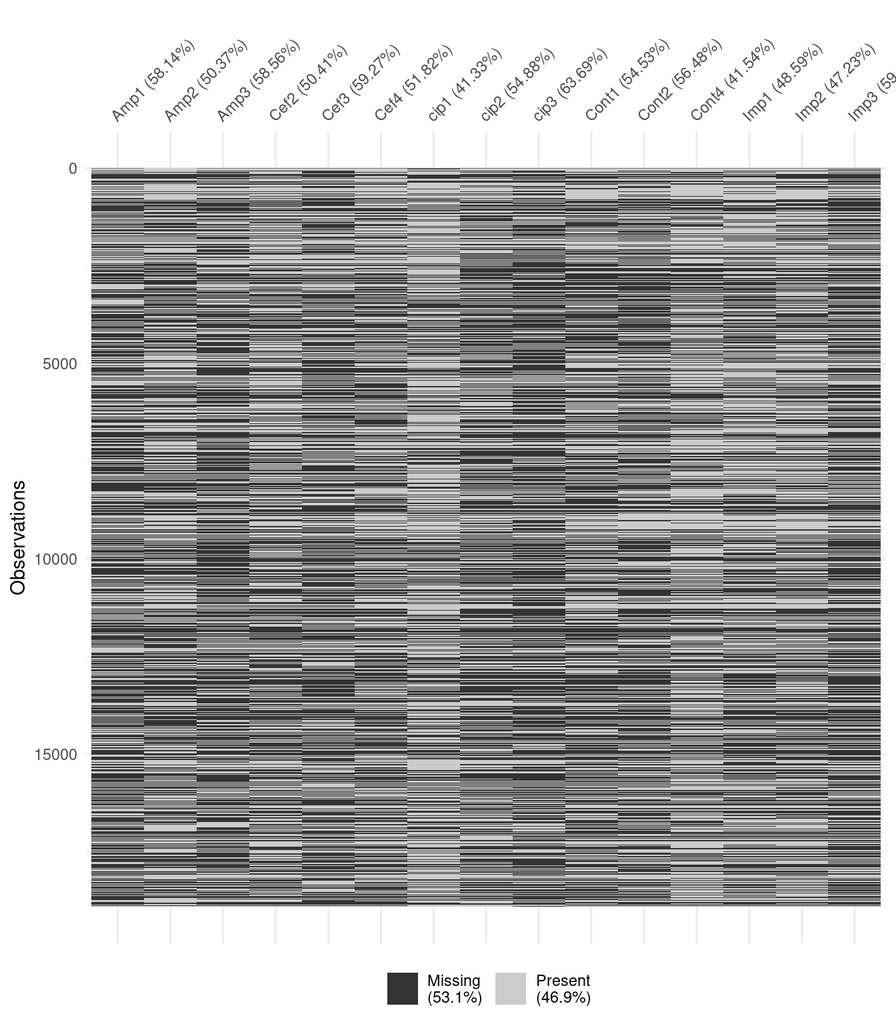

Figure 1: Distribution of missing values at peptide level.

```r
data_ <- as.data.frame(assay(fts[["peptides"]]))
colnames(data_) <- fts$sample_names
naniar::vis_miss(data_)
```

Now, we will aggregate at protein level by computing the median and examining the distribution of missing values.

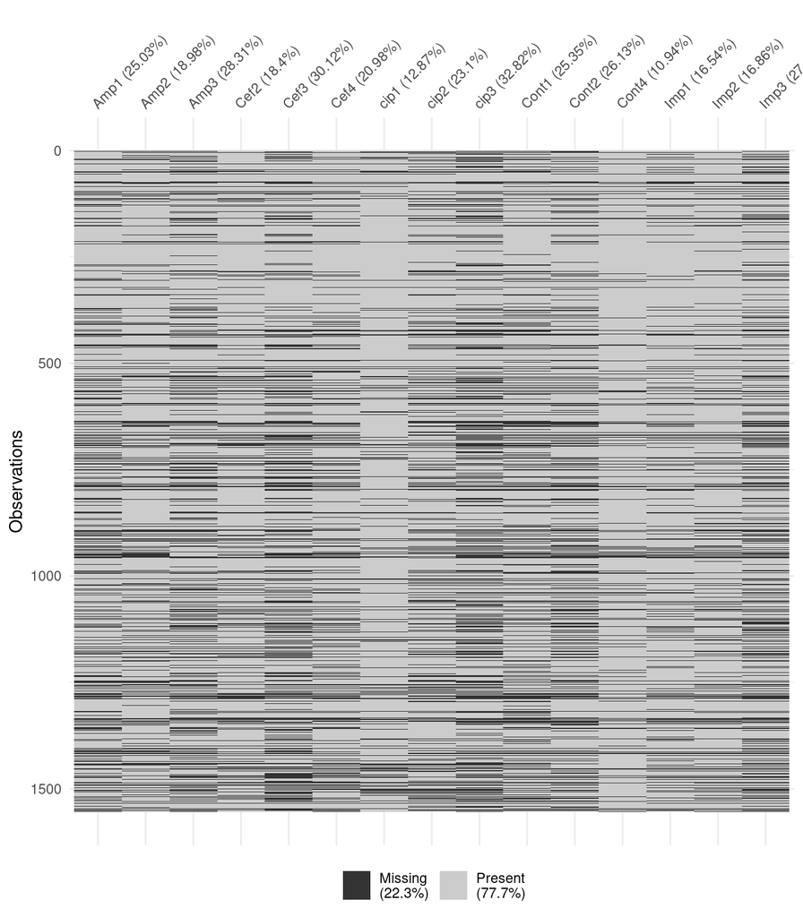

Figure 2: Distribution of missing values at protein level.

```r
fts <- aggregateFeatures(object = fts, i = "peptides", fcol = "protein",
                         name = "proteins", fun = colMedians, na.rm = TRUE)
assayNames(fts[["proteins"]])[1L] <- "intensity"
colData(fts[["proteins"]]) <- col_data
data_ <- as.data.frame(assay(fts[["proteins"]]))
colnames(data_) <- fts$sample_names
naniar::vis_miss(data_)
```

Note, that the percentage of missing values at protein level is 22.26%. From Figure 1 and Figure 2 we can see that the missing values at peptide level are greater than that of protein level (as expected). This fact will guide our decision on the imputation technique.

# 3 Processing steps

Processing the raw data set is a crucial task when analyzing omics data. Proteomics quantification data have technical variability due to experimental processes. Removing that variability and keeping only the biological variability is fundamental for later downstream statistical analysis.

It is important to mention that these processing steps are performed at the protein level, since as shown in Figure 1 and Figure 2, there are many missing values at the peptide level, which can affect proper corrections. Furthermore, the imputation and normalization are performed at $\log_2$ transformed intensity.

Table 1 summarizes the processing steps used by Margalit, Carolan, and Walsh (2022) and the alternative approach adopted in this project. The imputation was performed by sampling from a Normal distribution with downshift of 1.8 times the mean standard deviation (SD) of all measured values and a width of 0.3 times this SD.

```r
tab_steps_comparison <- dplyr::tibble(
  "Steps" = c("Aggregation", "Filter", "Imputation", "Normalization"),
  "Margalit et al. (2022)" = c("?", "?", "Sampling from Normal distribution",
                               "Z-score"),
  "Alternative" = c("Median", "Pct Missing $> 50%$ and Number peptides $<= 3$",
                    "$k$-NN", "Faster cyclic loess"))

kableExtra::kbl(x = tab_steps_comparison) |>
  kableExtra::kable_styling(bootstrap_options = "striped", full_width = FALSE)
```

Table 1: Comparison between the processed steps.

| Steps | Margalit et al. (2022) | Alternative |
| --- | --- | --- |
| Aggregation | ? | Median |
| Filter | ? | Pct Missing $> 50%$ and Number peptides $<= 3$ |
| Imputation | Sampling from Normal distribution | $k$-NN |
| Normalization | Z-score | Faster cyclic loess |

## 3.1 Filtering

We start the processing step by filtering out uninteresting proteins, adopting two filters to do so. First, we filter proteins that have less than or equal to 3 peptides matches, and secondly, we filter proteins with more than 50% missing values across all samples.

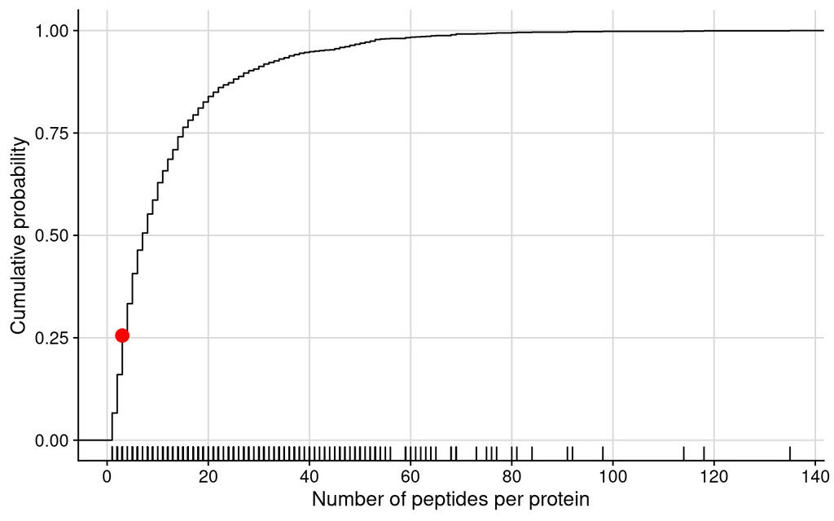

Figure 3: Distribution of the number of peptide per proteins.

```r
ggplot(data = data.frame(x = rowData(fts[["proteins"]])$.n), aes(x = x)) +
  stat_ecdf() +
  geom_point(data = data.frame(x = 3, y = mean(rowData(fts[["proteins"]])$.n <= 3)),
             aes(x = x, y = y), col = "red", size = 4) +
  geom_rug() +
  labs(x = "Number of peptides per protein", y = "Cumulative probability") +
  scale_x_continuous(breaks = scales::pretty_breaks(6))
```

Second, we note that from Figure 4 that 50% of the proteins (total of 778) do not have any missing values in all samples. However, 21% of the proteins have more than 50% missing values across all samples (see the red dot). Therefore, we will remove these above mentioned proteins.

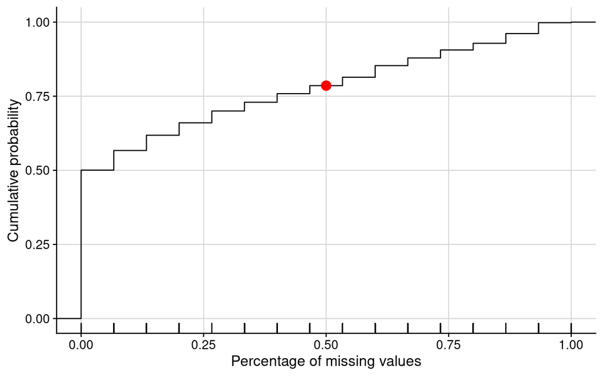

Figure 4: Cumulative distribution of the percentage of missing values at proteins level across samples.

```r
na_proteins <- rowMeans(is.na(assay(fts[["proteins"]])))
th <- 0.50
ggplot(data = data.frame(x = na_proteins), aes(x = x)) +
  stat_ecdf() +
  geom_point(data = data.frame(x = th, y = mean(na_proteins <= th)),
             aes(x = x, y = y), col = "red", size = 4) +
  geom_rug() +
  labs(x = "Percentage of missing values", y = "Cumulative probability")

# Filtering
fts[["proteins"]] <- fts[["proteins"]][na_proteins < th, ]
fts[["proteins"]] <- fts[["proteins"]][rowData(fts[["proteins"]])$.n > 3, ]
```

## 3.2 Imputation

The imputation of missing at random (MAR) values is widely discussed in both theory and real practice. In the context of label-free quantitative proteomics data Lazar et al. (2016) performed a series of imputation method comparisons using simulated and read data set. The authors showed that overall the MAR-devoted methods, specifically *k*-NN, SVD, and MLE provided good performance for the imputation task.

As mentioned the imputation technique used by Perseus is sampling from a Normal distribution with shifts in the mean and variance that mimic low undetected intensities, therefore the missing values are filled by low values. This imputed method could lead to an inflation in the variance producing differences that would not appear.

In this study, we consider the *k*-NN method implemented in the Bioconductor R package `impute` (Hastie et al. 2022). For each protein abundance, $x_i$ the method the *k*-NN method works as follows:

1. Calculate the Euclidean distance between $\mathbf{x}_i^c$ and all other proteins in $\mathbf{X}^c$;
2. Identify the $k$ closest proteins;
3. Impute the missing values of $x_i$ using the average of the corresponding $k$ closest.

Here, $\mathbf{x}_i^c$ and $\mathbf{X}_i^c$ denote the complete observed values of $x_i$ and all other proteins.

```r
assay(fts[["proteins"]], "log2_intensity") <- log2(assay(fts[["proteins"]]))
logx_imputed <- impute::impute.knn(
  data = assay(fts[["proteins"]], "log2_intensity"), k = 10L)
assay(fts[["proteins"]], "log2_imputed") <- logx_imputed$data
```

## 3.3 Normalization

Normalization aims to remove systematic differences due to experimental instrumentation, ensuring that any observed heterogeneity or differential expression between samples is driven by biological and not technical biases. For label-free proteomics quantification data Valikangas, Suomi, and Elo (2018) systematically reviewed normalization methods using spike-in data sets. The authors showed that the faster cyclic loess normalization introduced by Ballman et al. (2004) gives well performing results for proteomics data. We use the faster cyclic loess for normalization on the imputed log2 intensity. This method is implemented in `normalizeCyclicLoess` function with the argument `method = "fast"` from the `limma` package (Ritchie et al. 2015).

```r
assay(fts[["proteins"]], "log2_normalized") <- limma::normalizeCyclicLoess(
  x = assay(fts[["proteins"]], "log2_imputed"), method = "fast")
```

# 4 Comparison

This section shows a graphical comparison between the data set processed by Margalit, Carolan, and Walsh (2022) and our proposed processing.

Figure 5 shows the protein abundance densities coloured by group and faceted according to the transformation performed. The Unprocessed intensity panel shows a very highly skewed distribution. The other panels show the transformed intensity where we can see that the distribution is more symmetric. When comparing the two below panels we can observe the effect of normalization.

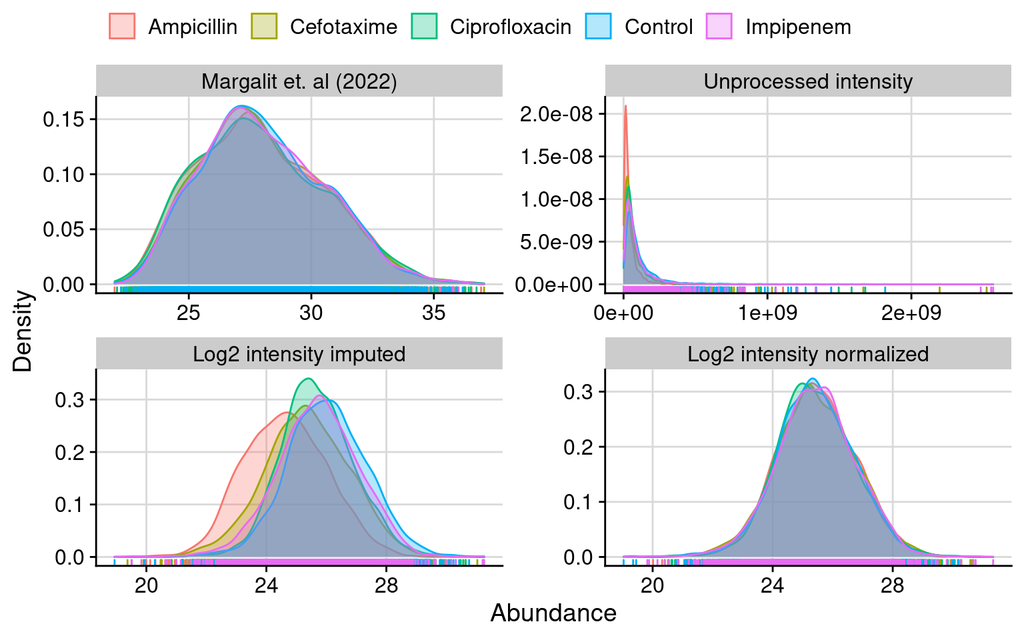

Figure 5: Proteins abundance densities by transformation and group.

```r
ggplot(data_pivotted, aes(x = value, fill = group, col = group)) +
  facet_wrap(~variable, scales = "free") +
  geom_density(alpha = 0.3) +
  geom_rug(show.legend = FALSE) +
  labs(x = "Abundance", y = "Density", fill = "", col = "")
```

Figure 6 gives a comparison between the densities by the processing methods. We clearly see that the distribution by Margalit, Carolan, and Walsh (2022) are spread our more than ours, which are more symmetric.

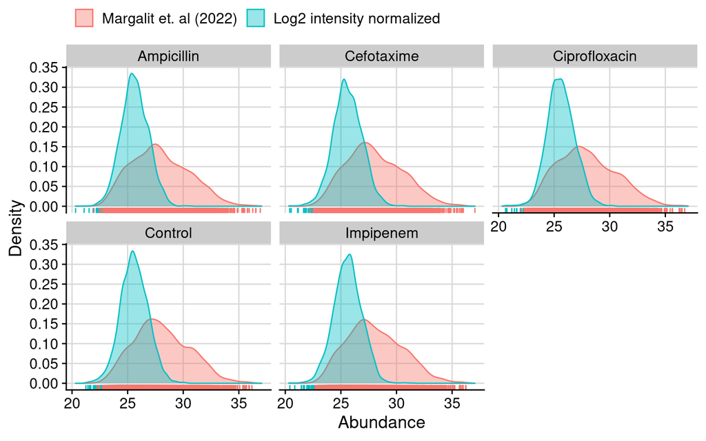

Figure 6: Comparison of proteins abundance densities between the processing approaches.

```r
data_pivotted |>
  dplyr::filter(variable %in% c("Margalit et. al (2022)",
                         "Log2 intensity normalized"),
                proteins %in% rownames(se_margalit)) |>
  ggplot(aes(x = value, fill = variable, col = variable)) +
  facet_wrap(~group) +
  geom_density(alpha = 0.4) +
  geom_rug(show.legend = FALSE) +
  labs(x = "Abundance", y = "Density", fill = "", col = "") +
  scale_x_continuous(breaks = scales::pretty_breaks(6)) +
  scale_y_continuous(breaks = scales::pretty_breaks(6))
```

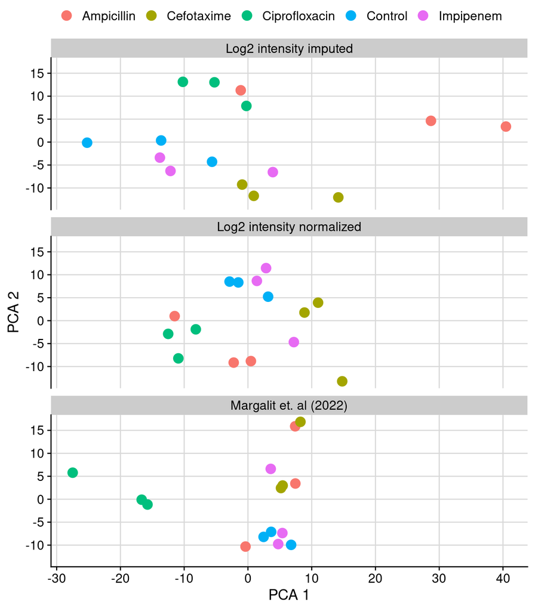

Figure 7: PCA performed on imputed $\log_2$ intensity before and after normalization.

```r
pca_non_normalized <- scater::calculatePCA(
  x = fts[["proteins"]], exprs_values = "log2_imputed")
pca_normalized <- scater::calculatePCA(
  x = fts[["proteins"]], exprs_values = "log2_normalized")
pca_margalit <- scater::calculatePCA(
  x = se_margalit, exprs_values = "log_intensity")

tb <- dplyr::as_tibble(pca_non_normalized) |>
  dplyr::mutate(sample = rownames(pca_non_normalized),
                group = colData(fts[["proteins"]])$group,
                measure = "Log2 intensity imputed") |>
  dplyr::bind_rows(
    dplyr::as_tibble(pca_normalized) |>
      dplyr::mutate(group = colData(fts[["proteins"]])$group,
                    measure = "Log2 intensity normalized")) |>
  dplyr::bind_rows(
    dplyr::as_tibble(pca_margalit) |>
      dplyr::mutate(group = colData(se_margalit)$group,
                    measure = "Margalit et. al (2022)"))

ggplot(tb, aes(x = PC1, y = PC2, col = group)) +
  facet_wrap(~measure, ncol = 1) +
  geom_point(size = 4) +
  labs(x = "PCA 1", y = "PCA 2", col = "") +
  scale_x_continuous(breaks = scales::pretty_breaks(8)) +
  scale_y_continuous(breaks = scales::pretty_breaks(8))
```

## References

Ballman, Karla V., Diane E. Grill, Ann L. Oberg, and Terry M. Therneau. 2004. “Faster cyclic loess: normalizing RNA arrays via linear models.” *Bioinformatics* 20 (16): 2778–86. https://doi.org/10.1093/bioinformatics/bth327.

Gatto, Laurent, and Christophe Vanderaa. 2022. *QFeatures: Quantitative Features for Mass Spectrometry Data*. https://github.com/RforMassSpectrometry/QFeatures.

Hastie, Trevor, Robert Tibshirani, Balasubramanian Narasimhan, and Gilbert Chu. 2022. *Impute: Imputation for Microarray Data*.

Lazar, Cosmin, Laurent Gatto, Myriam Ferro, Christophe Bruley, and Thomas Burger. 2016. “Accounting for the Multiple Natures of Missing Values in Label-Free Quantitative Proteomics Data Sets to Compare Imputation Strategies.” *Journal of Proteome Research* 15 (4): 1116–25. https://doi.org/10.1021/acs.jproteome.5b00981.

Margalit, Anatte, James C. Carolan, and Fiona Walsh. 2022. “Global Protein Responses of Multidrug Resistance Plasmid-Containing Escherichia Coli to Ampicillin, Cefotaxime, Imipenem and Ciprofloxacin.” *Journal of Global Antimicrobial Resistance* 28: 90–96. https://doi.org/https://doi.org/10.1016/j.jgar.2021.12.006.

Morgan, Martin, Valerie Obenchain, Jim Hester, and Hervé Pagès. 2022. *SummarizedExperiment: SummarizedExperiment Container*. https://bioconductor.org/packages/SummarizedExperiment.

Ritchie, Matthew E., Belinda Phipson, Di Wu, Yifang Hu, Charity W. Law, Wei Shi, and Gordon K. Smyth. 2015. “limma Powers Differential Expression Analyses for RNA-Sequencing and Microarray Studies.” *Nucleic Acids Research* 43 (7): e47. https://doi.org/10.1093/nar/gkv007.

Valikangas, Tommi, Tomi Suomi, and Laura L Elo. 2018. “A Systematic Evaluation of Normalization Methods in Quantitative Label-Free Proteomics.” *Briefings in Bioinformatics* 19 (1): 1–11. https://doi.org/10.1093/bib/bbw095.